# Linear Algebra Review II

- Nate Olson
- June 29, 2016

## Matricies and Linear Regression

What we are working towards….

$$Y_i = \beta_0 + \beta_1 x_i + \varepsilon_i, i=1,\dots,N$$

as:

$$\,
\begin{pmatrix}
Y_1\\
Y_2\\
\vdots\\
Y_N
\end{pmatrix} =
\begin{pmatrix}
1&x_1\\
1&x_2\\
\vdots\\
1&x_N
\end{pmatrix}
\begin{pmatrix}
\beta_0\\
\beta_1
\end{pmatrix} +
\begin{pmatrix}
\varepsilon_1\\
\varepsilon_2\\
\vdots\\
\varepsilon_N
\end{pmatrix}$$

or simply:

$$\mathbf{Y}=\mathbf{X}\boldsymbol{\beta}+\boldsymbol{\varepsilon}$$

## 1.3 Vector Equations

### Definitions

- vector - a list of numbers
- column vector - one column matrix
- zero vector - all values in a vector are zero
- scalar - real numbers that have magnitude but no direction wikipedia
- span - subset of a vector

### Parallelogram Rule for Addition

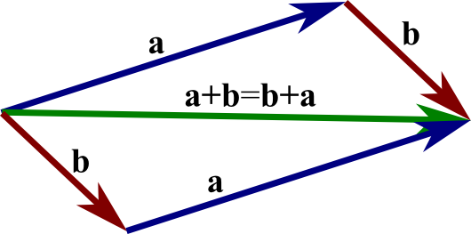

http://i.stack.imgur.com/O6Ved.png

### Algebratic Properties of ${\rm I\!R}^n$

$\mathbf{u}$, $\mathbf{v}$, and $\mathbf{w}$ are vectors, where $c$ and $d$ are scalars

1. $\mathbf{u} + \mathbf{v} = \mathbf{v} + \mathbf{u}$
2. $(\mathbf{u} + \mathbf{v}) + \mathbf{w} = \mathbf{u} + (\mathbf{v} + \mathbf{w})$
3. $\mathbf{u} + 0 = 0 + \mathbf{u} = \mathbf{u}$
4. $\mathbf{u} + (-\mathbf{u}) = 0$, where $(-1)\mathbf{u} = -\mathbf{u}$
5. $c(\mathbf{u} + \mathbf{v}) = c\mathbf{u} + c\mathbf{v}$
6. $(c + d)\mathbf{u} = c\mathbf{u} + d\mathbf{u}$
7. $c(d\mathbf{u}) = (cd)(\mathbf{u})$
8. $1\mathbf{u} = \mathbf{u}$

## 1.4 The Matrix Equation $A\mathbf{x} = \mathbf{b}$

$A$ is a $m\times n$ matrix, with columns $\mathbf{a}_1$, …, $\mathbf{a}_n$, and if $\mathbf{x}$ is in ${\rm I\!R}^n$,

$$A\mathbf{x} =
\begin{bmatrix}
\mathbf{a}_1 & \mathbf{a}_2 & \dots & \mathbf{a}_n
\end{bmatrix}
\begin{bmatrix}
x_1\\
x_2\\
\vdots \\
x_n\\
\end{bmatrix} =
x_1\mathbf{a}_1 + x_2\mathbf{a}_2 + \dots + x_n\mathbf{a}_n$$

### Theorem 3

$\mathbf{A}$ is a $m\times n$ matrix with columns $\mathbf{a}_1, \dots, \mathbf{a}_n$, $\mathbf{b}$ is in ${\rm I\!R}^m$

The solutions of $x$ (and solution set for the augmented matrix) are all the same.

- $\mathbf{A}x=\mathbf{b}$
- $x_1\mathbf{a}_1 + x_2\mathbf{a}_2 + \dots + x_n\mathbf{a}_n = \mathbf{b}$
- $\begin{bmatrix} \mathbf{a}_1 & \mathbf{a}_2 & \dots & \mathbf{a}_n & \mathbf{b}\end{bmatrix}$

### Existence of Solutions

Only solution if and only if $\mathbf{b}$ is a linear combination of the columns of $A$

### Theorem 4

1. for all real $\mathbf{b}$, $\mathbf{A}x=\mathbf{b}$ has a solution
2. for all real $\mathbf{b}$, $\mathbf{b}$ is a linear combination of columns in $\mathbf{A}$
3. column of $\mathbf{A}$ span ${\rm I\!R}^m$ - I think this means the columns are real as well
4. $\mathbf{A}$ has a pivot position in every row.

### Computation of $A\mathbf{x}$

Introduction of the identity matrix concept - the identity matrix is key to finding inverse of a matrix

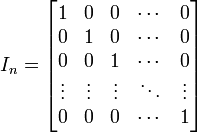

https://tfetimes.com/c-identity-matrix/

### Theorem 5

Assuming the following,

- $\mathbf{A}$ is a $m\times n$ matrix
- $\mathbf{u}$ and $\mathbf{v}$ are real vectors
- $c$ is a scalar

Then

- $\mathbf{A}(\mathbf{u} + \mathbf{v}) = \mathbf{A}\mathbf{u} + \mathbf{A}\mathbf{v}$
- $\mathbf{A}(c\mathbf{u}) = c(\mathbf{A}\mathbf{u})$